# R Workshop @TESRI

## 寬型表格(二維表)：報表資料

通常是原始資料經過樞紐分析後的樣子，有欄的名稱以及列的名稱

範例：呈現樣區內每一個樣點的總個體數

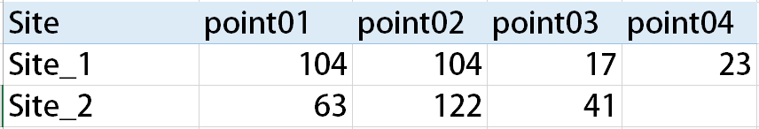

## 錯誤示範: 電腦看不懂的資料

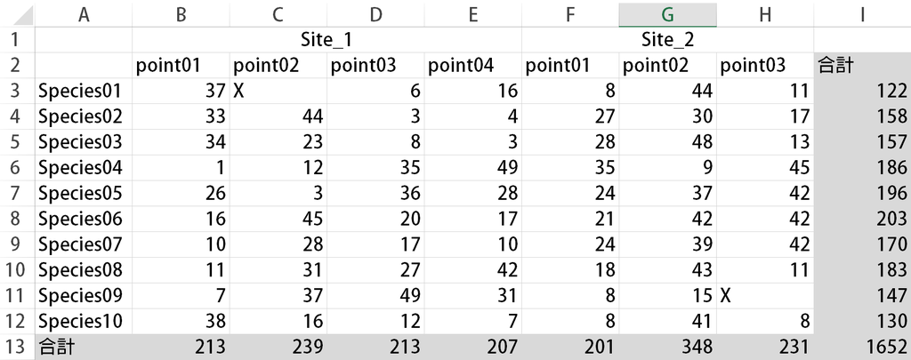

1. 合併儲存格
2. 不是所有欄位都有欄位名稱
3. 資料格式不一致
4. 保留非原始資料的欄位(合計欄、列)

## 錯誤示範：電腦看不懂的資料 II

```r
w_table <- read.csv("w_data.csv", sep = ",")

w_table
```

```
##            X  Site_1     X.1     X.2     X.3  Site_2     X.4     X.5   X.6
## 1            point01 point02 point03 point04 point01 point02 point03 Total
## 2  Species01      37       X       6      16       8      44      11   122
## 3  Species02      33      44       3       4      27      30      17   158
## 4  Species03      34      23       8       3      28      48      13   157
## 5  Species04       1      12      35      49      35       9      45   186
## 6  Species05      26       3      36      28      24      37      42   196
## 7  Species06      16      45      20      17      21      42      42   203
## 8  Species07      10      28      17      10      24      39      42   170
## 9  Species08      11      31      27      42      18      43      11   183
## 10 Species09       7      37      49      31       8      15       X   147
## 11 Species10      38      16      12       7       8      41       8   130
## 12     Total     213     239     213     207     201     348     231  1652
```

## 一些補充資訊…

## 不只是新手的常見問題

### Q1 函數套件五花八門，怎麼學RRRRRR！？

函數永遠學不完，而且還會一直開發新的，有要用到再來估狗就好

### Q2 遇到 error 怎麼辦 @_____@？

1. 先冷靜下來。看看 error 吐出的訊息是什麼，雖然都是英文，雖然好像又不太像英文(?)，但通常冷靜下來還是會找到幾個看得懂的字告訴你問題出在哪裡
2. 整串 error 訊息複製下來，貼上去問估狗大神

### Q3 我想用Ｒ做ＸＸＸ，但是沒有概念要怎麼做欸_(┐「ε:)_

關鍵字："想做的事(強烈建議用英文) + R" 去問估狗大神  
"merge data.frame R"、"data mining r"、"bar plot r"、"change axis text r"

估狗估狗估狗除了估狗還是估狗估狗估狗什麼都餵狗就對惹U・ω・U

## 學習 R 或幫助 debug 的地方

### 幾個還不錯的中/英文教材

1. [輕鬆學習 R 語言](http://www.learn-r-the-easy-way.tw) (有免費的線上電子書，也可以購買實體書支持一下作者)
2. [R 語言翻轉教室](https://datascienceandr.org/install.html?fbclid=IwAR1-2E0NrUauLO5doWLFYvxXTIP9nvbWvYVXPIIp2_ol_-RKPl4MZDh42bI) (在 R 裡面學習 R)
3. [How To Use R With Excel](https://rpubs.com/acolumbus/how-to-use-r-with-excel) (內有 excel 跟 R 之間的函式庫對應)
4. 官方 Cheat sheet 系列： [ggplot2](https://www.rstudio.com/wp-content/uploads/2015/03/ggplot2-cheatsheet.pdf)、 [dplyr](https://www.rstudio.com/wp-content/uploads/2015/02/data-wrangling-cheatsheet.pdf) 等

### Debug 專區

[stackoverflow](https://stackoverflow.com/) (通常估狗問題跑出來的前幾個連結就是他了)

### 進階版

[Github](https://github.com/) (號稱工程師的臉書www 很多package會發布在這邊)

## 一些幫助你精進 coding 技巧的撇步

### 1. 學英文

### 2. 學會估狗

### 3. 學會拆解問題

### 4. 多看多寫就對了

## 沒有最好的工具，只有最適合你的工具。

沒有 **懂得 coding 就比較厲害** 這回事！ (只有比較宅 (｢･ω･)｢)

R 只是眾多資料分析工具的一種，讓你達到目的的手段之一，Excel、Power BI 也都是很好的工具，選工具的重點還是看你要做什麼以及你的使用習慣。

今天的課程結束後，如果覺得拖拉點選的圖形化介面工具還是比較適合自己，可以回去投入 Excel 的懷抱沒關係，真的（宅宅的講師與小助教們不會難過（吧？））。工具就是要拿來減輕你的負擔，如果使用工具反而讓你覺得事倍功半，那就失去了使用工具的意義了。但我覺得在時間許可的情況下，可以給自己一些機會去接觸不同的工具，讓未來在處理事情時有不同的選項。